# Pertemuan-2

## Library/Packages

```r
library("forecast")
```

```r
library("graphics")
library("TTR")
library("TSA")
```

## Impor Data

```r
library(rio) #install packages jika belum ada
data1 <- import("https://github.com/kamaldims/MPDW/raw/refs/heads/main/Kurs%20Jual%20Rataan%20USD%20Fix.xlsx")


#via csv gunakan read.csv("namafile.csv")
#data1 <- read.csv("Data_1.csv")

# menampilkan 5 data pertama
head(data1)
```

```
##   Minggu Ke- Kurs Jual Rataan
## 1          1          12723.0
## 2          2          12688.6
## 3          3          12670.6
## 4          4          12542.8
## 5          5          12681.6
## 6          6          12721.0
```

## Eksplorasi Data

`View()` : menampilkan data dalam bentuk tabel, `str()` : menampilkan struktur data, `dim()` : menampilkan dimensi data

```r
View(data1)
str(data1)
```

```
## 'data.frame':    518 obs. of  2 variables:
##  $ Minggu Ke-      : num  1 2 3 4 5 6 7 8 9 10 ...
##  $ Kurs Jual Rataan: num  12723 12689 12671 12543 12682 ...
```

```r
dim(data1)
```

```
## [1] 518   2
```

Mengubah data agar terbaca sebagai data deret waktu dengan fungsi `ts()` .

```r
data1.ts <- ts(data1$`Kurs Jual Rataan`)
```

Menampilkan ringkasan data

```r
summary(data1.ts)
```

```
##    Min. 1st Qu.  Median    Mean 3rd Qu.    Max.
##   12543   13667   14375   14510   15213   16933
```

## Single Moving Average & Double Moving Average

### Pembagian Data

Pembagian data latih dan data uji dilakukan dengan perbandingan 80% data latih dan 20% data uji.

```r
# hitung jumlah data
n <- nrow(data1[313:415,])
data2 <- data1[313:415,]

# tentukan batas 80%
n_train <- floor(0.8 * n)

# bagi data
training_ma <- data1[313:(313+n_train), ]
testing_ma  <- data1[(314+n_train):415, ]

# ubah ke time series
train_ma.ts <- ts(training_ma$`Kurs Jual Rataan`)
test_ma.ts  <- ts(testing_ma$`Kurs Jual Rataan`)
```

Eksplorasi data dilakukan pada keseluruhan data, data latih serta data uji menggunakan plot data deret waktu.

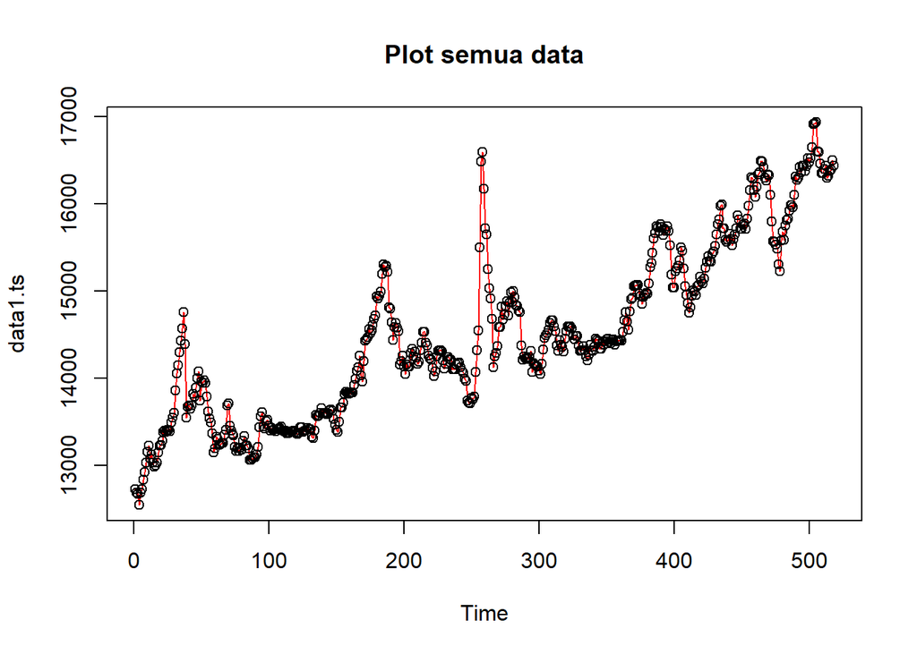

```r
#eksplorasi keseluruhan data
plot(data1.ts, col="red",main="Plot semua data")
points(data1.ts)
```

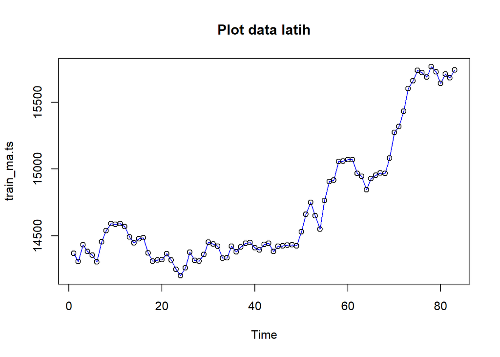

```r
#eksplorasi data latih
plot(train_ma.ts, col="blue",main="Plot data latih")
points(train_ma.ts)
```

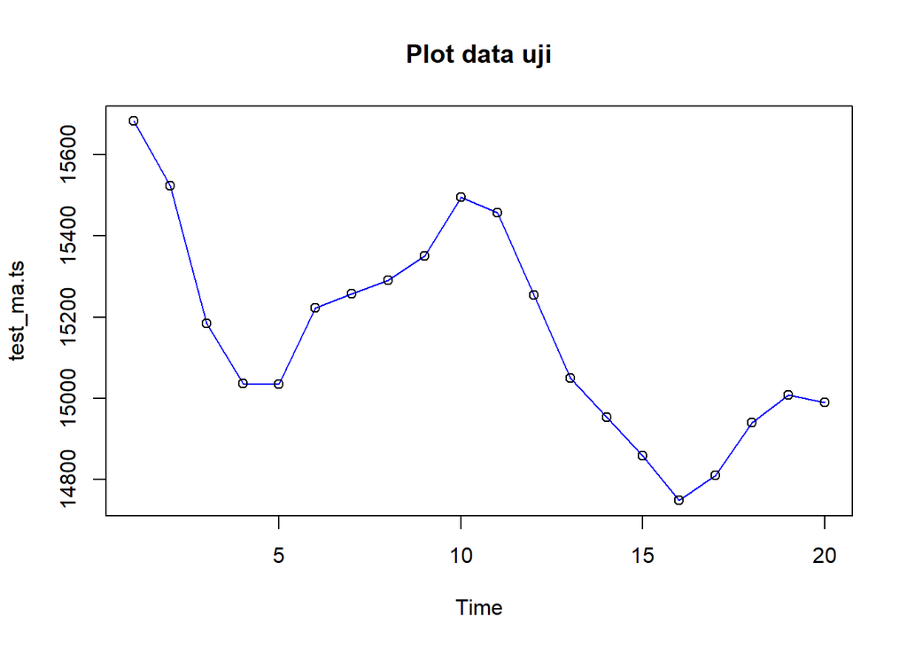

```r
#eksplorasi data uji
plot(test_ma.ts, col="blue",main="Plot data uji")
points(test_ma.ts)
```

Eksplorasi data juga dapat dilakukan menggunakan package `ggplot2` dengan terlebih dahulu memanggil library *package* `ggplot2`.

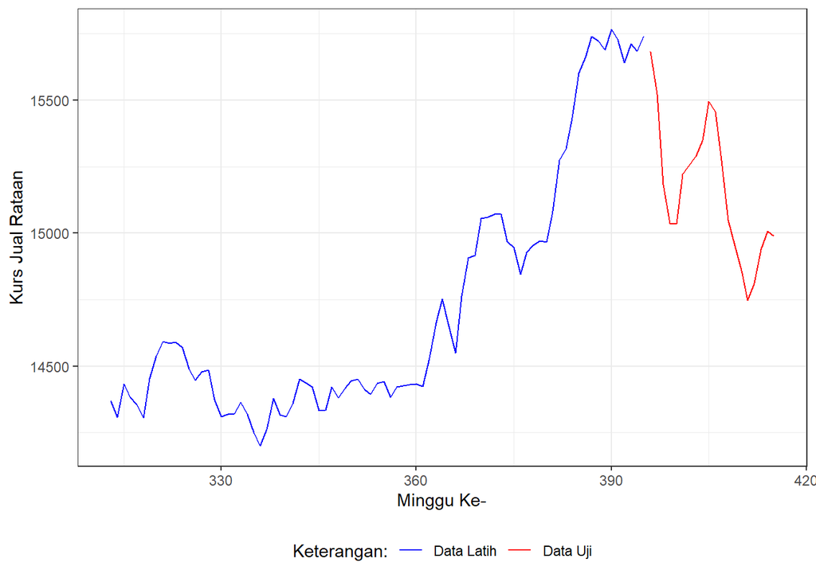

```r
library(ggplot2)
ggplot() +
  geom_line(data = training_ma, aes(x = `Minggu Ke-`, y = `Kurs Jual Rataan`, col = "Data Latih")) +
  geom_line(data = testing_ma, aes(x = `Minggu Ke-`, y = `Kurs Jual Rataan`, col = "Data Uji")) +
  labs(x = "Minggu Ke-", y = "Kurs Jual Rataan", color = "Legend") +
   scale_colour_manual(name="Keterangan:", breaks = c("Data Latih", "Data Uji"),
                      values = c("blue", "red")) +
  theme_bw() + theme(legend.position = "bottom",
                     plot.caption = element_text(hjust=0.5, size=12))
```

### Single Moving Average (SMA)

Pemulusan menggunakan metode SMA dilakukan dengan fungsi `SMA()`. Dalam hal ini akan dilakukan pemulusan dengan parameter `m=4`.

```r
data.sma<-SMA(train_ma.ts, n=4)
data.sma
```

```
## Time Series:
## Start = 1
## End = 83
## Frequency = 1
##  [1]       NA       NA       NA 14373.41 14370.09 14369.64 14374.87 14413.66
##  [9] 14472.60 14542.65 14576.77 14584.76 14559.64 14524.82 14496.77 14475.57
## [17] 14445.97 14411.90 14372.06 14330.95 14329.14 14331.50 14313.77 14283.82
## [25] 14257.89 14272.31 14289.19 14316.28 14340.90 14359.44 14389.99 14418.23
## [33] 14411.40 14382.21 14378.34 14367.78 14388.64 14415.92 14422.91 14430.65
## [41] 14424.92 14422.71 14420.90 14413.71 14420.85 14418.49 14415.47 14428.08
## [49] 14428.69 14455.07 14512.86 14592.50 14648.88 14653.56 14679.18 14717.93
## [57] 14784.76 14911.29 14985.15 15026.11 15064.45 15042.39 15013.65 14957.57
## [65] 14921.84 14918.37 14924.80 14954.90 14993.44 15073.69 15160.38 15276.96
## [73] 15407.35 15503.88 15609.61 15682.12 15703.38 15729.56 15726.64 15706.09
## [81] 15711.97 15691.42 15694.78
```

Data pemulusan pada `Minggu Ke-t` selanjutnya digunakan sebagai nilai peramalan pada `Minggu Ke-t+1` sehingga hasil peramalan 1 `Minggu Ke-` kedepan adalah sebagai berikut.

```r
data.ramal<-c(NA,data.sma)
data.ramal #forecast 1 `Minggu Ke-t` ke depan
```

```
##  [1]       NA       NA       NA       NA 14373.41 14370.09 14369.64 14374.87
##  [9] 14413.66 14472.60 14542.65 14576.77 14584.76 14559.64 14524.82 14496.77
## [17] 14475.57 14445.97 14411.90 14372.06 14330.95 14329.14 14331.50 14313.77
## [25] 14283.82 14257.89 14272.31 14289.19 14316.28 14340.90 14359.44 14389.99
## [33] 14418.23 14411.40 14382.21 14378.34 14367.78 14388.64 14415.92 14422.91
## [41] 14430.65 14424.92 14422.71 14420.90 14413.71 14420.85 14418.49 14415.47
## [49] 14428.08 14428.69 14455.07 14512.86 14592.50 14648.88 14653.56 14679.18
## [57] 14717.93 14784.76 14911.29 14985.15 15026.11 15064.45 15042.39 15013.65
## [65] 14957.57 14921.84 14918.37 14924.80 14954.90 14993.44 15073.69 15160.38
## [73] 15276.96 15407.35 15503.88 15609.61 15682.12 15703.38 15729.56 15726.64
## [81] 15706.09 15711.97 15691.42 15694.78
```

```r
data.gab<-cbind(
  aktual=c(data1.ts),
  pemulusan=c(data.sma,rep(NA,20)),
  ramalan=c(data.ramal,rep(data.ramal[length(data.ramal)],19)))
data.gab #forecast 24 `Minggu Ke-t` ke depan
```

```
##          aktual pemulusan  ramalan
##   [1,] 12723.00        NA       NA
##   [2,] 12688.60        NA       NA
##   [3,] 12670.60        NA       NA
##   [4,] 12542.80  14373.41       NA
##   [5,] 12681.60  14370.09 14373.41
##   [6,] 12721.00  14369.64 14370.09
##   [7,] 12837.20  14374.87 14369.64
##   [8,] 12919.40  14413.66 14374.87
##   [9,] 13025.40  14472.60 14413.66
##  [10,] 13151.20  14542.65 14472.60
##  [11,] 13227.60  14576.77 14542.65
##  [12,] 13076.60  14584.76 14576.77
##  [13,] 13120.40  14559.64 14584.76
##  [14,] 13026.80  14524.82 14559.64
```

[output cut: 504 more lines]

Adapun plot data deret waktu dari hasil peramalan yang dilakukan adalah sebagai berikut.

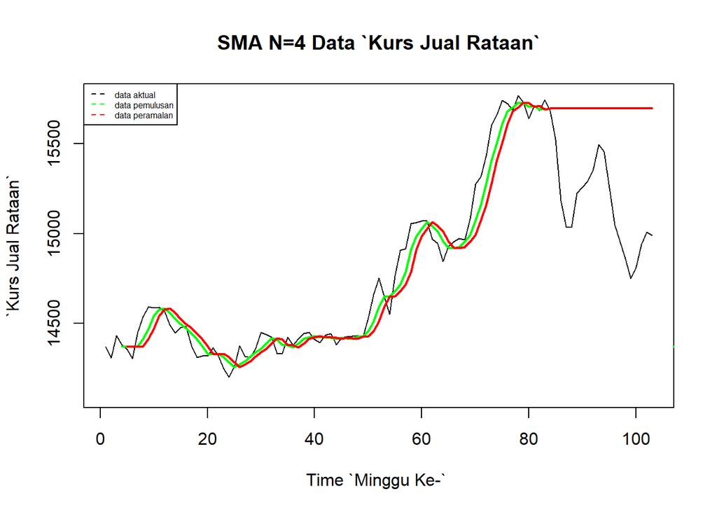

```r
ts.plot(data2, xlab="Time `Minggu Ke-` ", ylab="`Kurs Jual Rataan`", main= "SMA N=4 Data `Kurs Jual Rataan`", ylim=c(14100, max(data2, na.rm=TRUE)))
points(data2)
lines(data.gab[,2],col="green",lwd=2)
lines(data.gab[,3],col="red",lwd=2)
legend("topleft",c("data aktual","data pemulusan","data peramalan"), lty=8, col=c("black","green","red"), cex=0.5)
```

Selanjutnya perhitungan akurasi dilakukan dengan ukuran akurasi *Sum Squares Error* (SSE), *Mean Square Error* (MSE) dan *Mean Absolute Percentage Error* (MAPE). Perhitungan akurasi dilakukan baik pada data latih maupun pada data uji.

```r
#Menghitung nilai keakuratan data latih
error_train.sma = train_ma.ts-data.ramal[1:length(train_ma.ts)]

SSE_train.sma = sum(error_train.sma[5:length(train_ma.ts)]^2)
MSE_train.sma = mean(error_train.sma[5:length(train_ma.ts)]^2)
MAPE_train.sma = mean(abs((error_train.sma[5:length(train_ma.ts)]/train_ma.ts[5:length(train_ma.ts)])*100))

akurasi_train.sma <- matrix(c(SSE_train.sma, MSE_train.sma, MAPE_train.sma))
row.names(akurasi_train.sma)<- c("SSE", "MSE", "MAPE")
colnames(akurasi_train.sma) <- c("Akurasi m = 4")
akurasi_train.sma
```

```
##      Akurasi m = 4
## SSE   1.104244e+06
## MSE   1.397778e+04
## MAPE  5.911367e-01
```

```r
#Menghitung nilai keakuratan data uji
error_test.sma = test_ma.ts-data.gab[84:103,3]

SSE_test.sma = sum(error_test.sma^2)
MSE_test.sma = mean(error_test.sma^2)
MAPE_test.sma = mean(abs((error_test.sma/test_ma.ts*100)))

akurasi_test.sma <- matrix(c(SSE_test.sma, MSE_test.sma, MAPE_test.sma))
row.names(akurasi_test.sma)<- c("SSE", "MSE", "MAPE")
colnames(akurasi_test.sma) <- c("Akurasi m = 4")
akurasi_test.sma
```

```
##      Akurasi m = 4
## SSE   7.022629e+06
## MSE   3.511314e+05
## MAPE  3.572613e+00
```

Perhitungan akurasi menggunakan data latih menghasilkan nilai MAPE yang kurang dari 10% sehingga nilai akurasi ini dapat dikategorikan sebagai sangat baik.

### Double Moving Average (DMA)

Metode pemulusan Double Moving Average (DMA) pada dasarnya mirip dengan SMA. Namun demikian, metode ini lebih cocok digunakan untuk pola data trend. Proses pemulusan dengan rata rata dalam metode ini dilakukan sebanyak 2 kali.

```r
dma <- SMA(data.sma, n = 4)
At <- 2*data.sma - dma
Bt <- 2/(4-1)*(data.sma - dma)
data.dma<- At+Bt
data.ramal2<- c(NA, data.dma)

t = 1:20
f = c()

for (i in t) {
  f[i] = At[length(At)] + Bt[length(Bt)]*(i)
}

data.gab2 <- cbind(aktual = c(data1.ts),
                   pemulusan1 = c(data.sma,rep(NA,20)),
                   pemulusan2 = c(dma, rep(NA,20)),
                   At = c(At, rep(NA,20)),
                   Bt = c(Bt,rep(NA,20)),
                   ramalan = c(data.ramal2, f[-1]))
data.gab2
```

```
##          aktual pemulusan1 pemulusan2       At            Bt  ramalan
##   [1,] 12723.00         NA         NA       NA            NA       NA
##   [2,] 12688.60         NA         NA       NA            NA       NA
##   [3,] 12670.60         NA         NA       NA            NA       NA
##   [4,] 12542.80   14373.41         NA       NA            NA       NA
##   [5,] 12681.60   14370.09         NA       NA            NA       NA
##   [6,] 12721.00   14369.64         NA       NA            NA       NA
##   [7,] 12837.20   14374.87   14372.00 14377.73  1.909667e+00       NA
##   [8,] 12919.40   14413.66   14382.07 14445.26  2.106325e+01 14379.64
##   [9,] 13025.40   14472.60   14407.69 14537.51  4.327358e+01 14466.32
##  [10,] 13151.20   14542.65   14450.95 14634.36  6.113742e+01 14580.79
##  [11,] 13227.60   14576.77   14501.42 14652.12  5.023308e+01 14695.50
##  [12,] 13076.60   14584.76   14544.20 14625.33  2.704292e+01 14702.36
##  [13,] 13120.40   14559.64   14565.96 14553.32 -4.212583e+00 14652.37
##  [14,] 13026.80   14524.82   14561.50 14488.13 -2.445458e+01 14549.11
```

[output cut: 504 more lines]

Hasil pemulusan menggunakan metode DMA divisualisasikan sebagai berikut

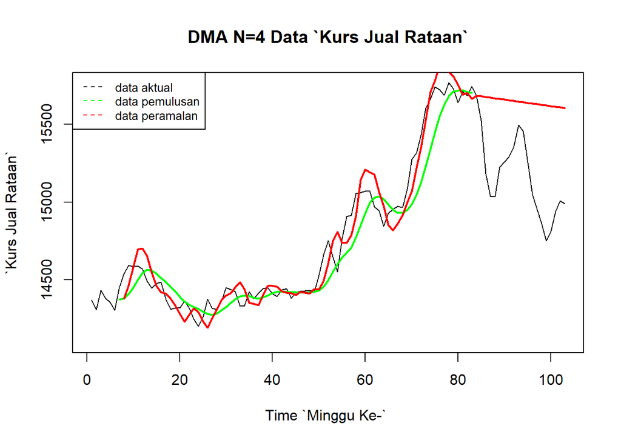

```r
ts.plot(data2, xlab="Time `Minggu Ke-` ", ylab="`Kurs Jual Rataan`", main= "DMA N=4 Data `Kurs Jual Rataan`",ylim=c(14100, max(data2, na.rm=TRUE)))
points(data2)
lines(data.gab2[,3],col="green",lwd=2)
lines(data.gab2[,6],col="red",lwd=2)
legend("topleft",c("data aktual","data pemulusan","data peramalan"), lty=8, col=c("black","green","red"), cex=0.8)
```

Selanjutnya perhitungan akurasi dilakukan baik pada data latih maupun data uji. Perhitungan akurasi dilakukan dengan ukuran akurasi SSE, MSE dan MAPE.

```r
#Menghitung nilai keakuratan data latih
error_train.dma = train_ma.ts-data.ramal2[1:length(train_ma.ts)]

SSE_train.dma = sum(error_train.dma[8:length(train_ma.ts)]^2)
MSE_train.dma = mean(error_train.dma[8:length(train_ma.ts)]^2)
MAPE_train.dma = mean(abs((error_train.dma[8:length(train_ma.ts)]/train_ma.ts[8:length(train_ma.ts)])*100))

akurasi_train.dma <- matrix(c(SSE_train.dma, MSE_train.dma, MAPE_train.dma))
row.names(akurasi_train.dma)<- c("SSE", "MSE", "MAPE")
colnames(akurasi_train.dma) <- c("Akurasi m = 4")
akurasi_train.dma
```

```
##      Akurasi m = 4
## SSE   7.824380e+05
## MSE   1.029524e+04
## MAPE  5.579196e-01
```

Perhitungan akurasi pada data latih menggunakan nilai MAPE menghasilkan nilai MAPE yang kurang dari 10% sehingga dikategorikan sangat baik. Selanjutnya, perhitungan nilai akurasi dilakukan pada data uji.

```r
#Menghitung nilai keakuratan data uji
error_test.dma = test_ma.ts-data.gab2[84:103,6]
SSE_test.dma = sum(error_test.dma^2)
MSE_test.dma = mean(error_test.dma^2)
MAPE_test.dma = mean(abs((error_test.dma/test_ma.ts*100)))

akurasi_test.dma <- matrix(c(SSE_test.dma, MSE_test.dma, MAPE_test.dma))
row.names(akurasi_test.dma)<- c("SSE", "MSE", "MAPE")
colnames(akurasi_test.dma) <- c("Akurasi m = 4")
akurasi_test.dma
```

```
##      Akurasi m = 4
## SSE   5.843114e+06
## MSE   2.921557e+05
## MAPE  3.239236e+00
```

Perhitungan akurasi menggunakan data latih menghasilkan nilai MAPE yang kurang dari 10% sehingga nilai akurasi ini dapat dikategorikan sebagai sangat baik.

## Single Exponential Smoothing & Double Exponential Smoothing

```r
# bagi data
training <- data1[313:(313+n_train), ]
testing  <- data1[(314+n_train):415, ]

# ubah ke time series
train.ts <- ts(training$`Kurs Jual Rataan`)
test.ts  <- ts(testing$`Kurs Jual Rataan`)
```

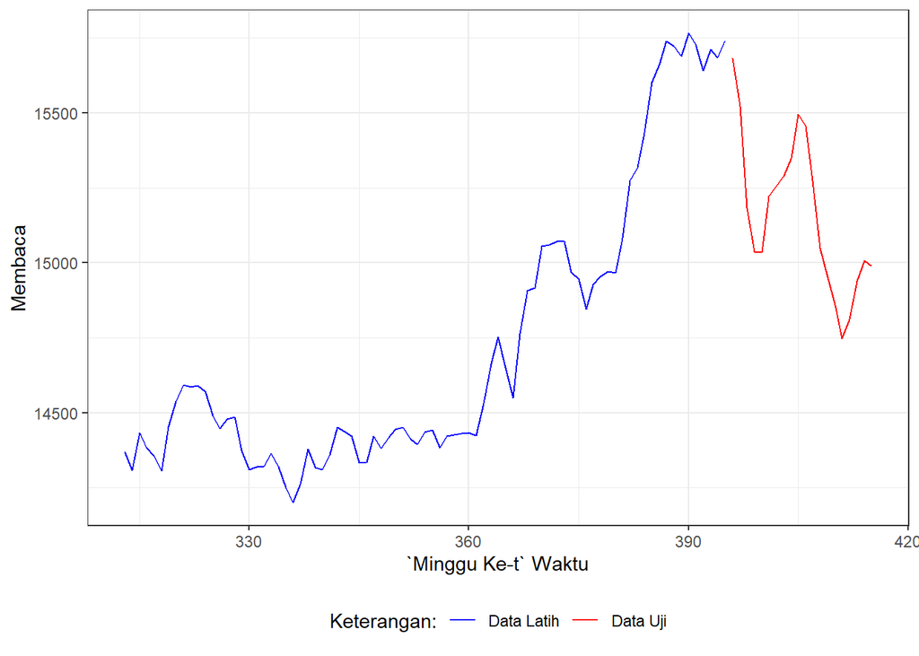

```r
#Eksplorasi dengan GGPLOT
library(ggplot2)
ggplot() +
  geom_line(data = training, aes(x = `Minggu Ke-`, y = `Kurs Jual Rataan`, col = "Data Latih")) +
  geom_line(data = testing, aes(x = `Minggu Ke-`, y = `Kurs Jual Rataan`, col = "Data Uji")) +
  labs(x = "`Minggu Ke-t` Waktu", y = "Membaca", color = "Legend") +
  scale_colour_manual(name="Keterangan:", breaks = c("Data Latih", "Data Uji"),
                      values = c("blue", "red")) +
  theme_bw() + theme(legend.position = "bottom",
                     plot.caption = element_text(hjust=0.5, size=12))
```

## Single Exponential Smoothing

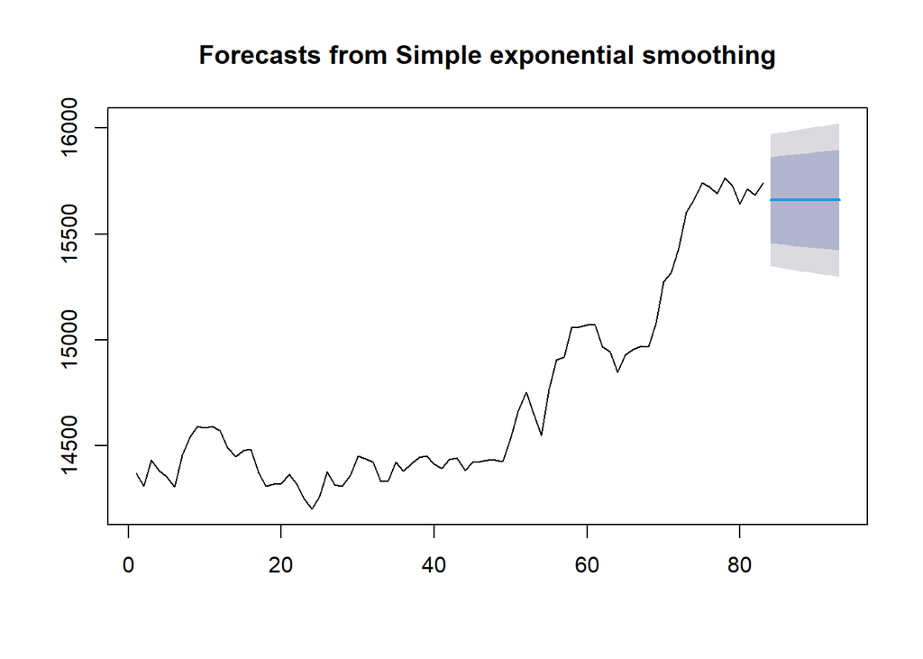

```r
#Cara 1 (fungsi ses)
ses.1 <- ses(train.ts, h = 10, alpha = 0.2)
plot(ses.1)
```

```r
ses.1
```

```
##    Point Forecast    Lo 80    Hi 80    Lo 95    Hi 95
## 84       15660.06 15456.79 15863.33 15349.18 15970.94
## 85       15660.06 15452.76 15867.36 15343.03 15977.09
## 86       15660.06 15448.81 15871.31 15336.99 15983.13
## 87       15660.06 15444.94 15875.18 15331.06 15989.06
## 88       15660.06 15441.13 15878.99 15325.24 15994.88
## 89       15660.06 15437.39 15882.73 15319.51 16000.61
## 90       15660.06 15433.71 15886.41 15313.88 16006.24
## 91       15660.06 15430.08 15890.04 15308.34 16011.78
## 92       15660.06 15426.52 15893.60 15302.89 16017.23
## 93       15660.06 15423.01 15897.11 15297.52 16022.60
```

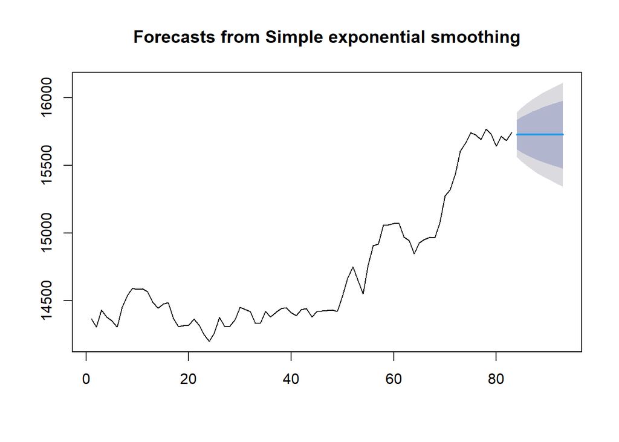

```r
ses.2<- ses(train.ts, h = 10, alpha = 0.7)
plot(ses.2)
```

```r
ses.2
```

```
##    Point Forecast    Lo 80    Hi 80    Lo 95    Hi 95
## 84       15726.28 15618.65 15833.91 15561.68 15890.88
## 85       15726.28 15594.90 15857.66 15525.36 15927.20
## 86       15726.28 15574.83 15877.73 15494.66 15957.90
## 87       15726.28 15557.13 15895.43 15467.58 15984.97
## 88       15726.28 15541.11 15911.45 15443.08 16009.47
## 89       15726.28 15526.37 15926.19 15420.54 16032.02
## 90       15726.28 15512.64 15939.92 15399.55 16053.01
## 91       15726.28 15499.75 15952.81 15379.83 16072.73
## 92       15726.28 15487.55 15965.01 15361.17 16091.39
## 93       15726.28 15475.94 15976.62 15343.42 16109.14
```

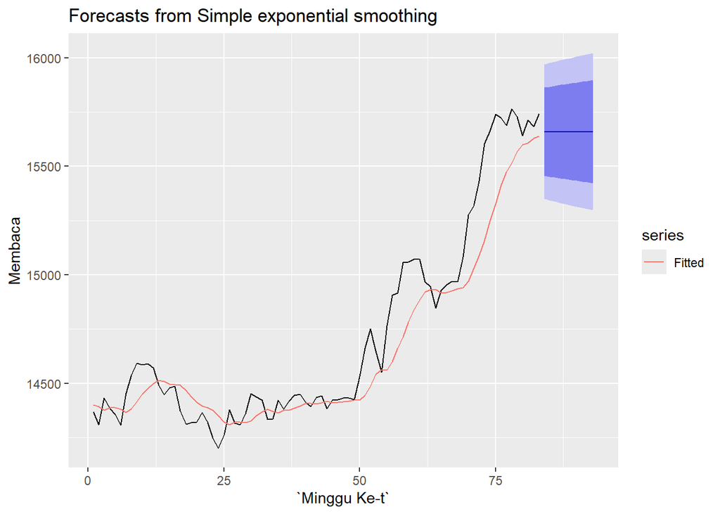

```r
autoplot(ses.1) +
  autolayer(fitted(ses.1), series="Fitted") +
  ylab("Membaca") + xlab("`Minggu Ke-t`")
```

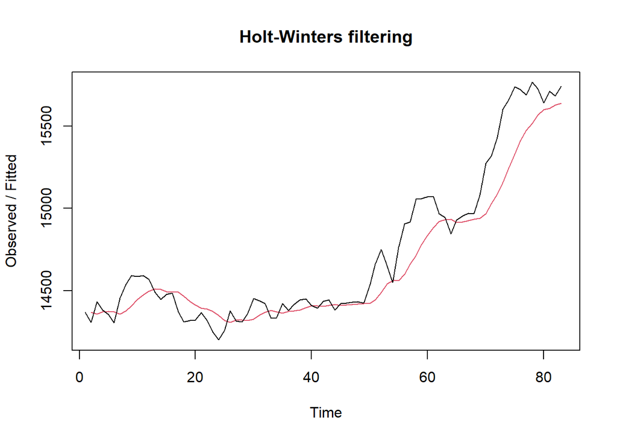

```r
#Cara 2 (fungsi Holtwinter)
ses1<- HoltWinters(train.ts, gamma = FALSE, beta = FALSE, alpha = 0.2)
plot(ses1)
```

```r
#ramalan
ramalan1<- forecast(ses1, h=10)
ramalan1
```

```
##    Point Forecast    Lo 80    Hi 80    Lo 95    Hi 95
## 84       15660.06 15483.79 15836.33 15390.48 15929.64
## 85       15660.06 15480.30 15839.82 15385.14 15934.98
## 86       15660.06 15476.88 15843.24 15379.90 15940.22
## 87       15660.06 15473.51 15846.61 15374.76 15945.36
## 88       15660.06 15470.21 15849.91 15369.71 15950.41
## 89       15660.06 15466.97 15853.15 15364.75 15955.37
## 90       15660.06 15463.78 15856.34 15359.87 15960.25
## 91       15660.06 15460.63 15859.49 15355.07 15965.05
## 92       15660.06 15457.54 15862.58 15350.34 15969.78
## 93       15660.06 15454.50 15865.62 15345.68 15974.44
```

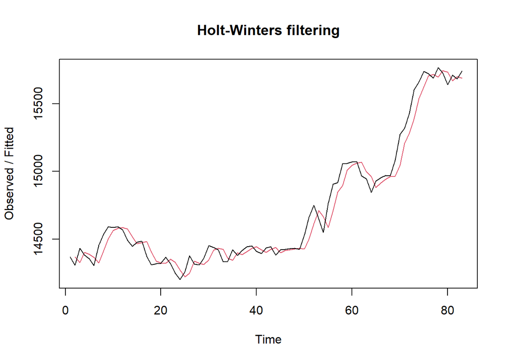

```r
ses2<- HoltWinters(train.ts, gamma = FALSE, beta = FALSE, alpha = 0.7)
plot(ses2)
```

```r
#ramalan
ramalan2<- forecast(ses2, h=10)
ramalan2
```

```
##    Point Forecast    Lo 80    Hi 80    Lo 95    Hi 95
## 84       15726.28 15623.05 15829.51 15568.41 15884.15
## 85       15726.28 15600.27 15852.29 15533.57 15918.99
## 86       15726.28 15581.02 15871.53 15504.13 15948.43
## 87       15726.28 15564.04 15888.51 15478.16 15974.40
## 88       15726.28 15548.68 15903.88 15454.66 15997.90
## 89       15726.28 15534.54 15918.02 15433.04 16019.52
## 90       15726.28 15521.38 15931.18 15412.91 16039.65
## 91       15726.28 15509.01 15943.55 15393.99 16058.57
## 92       15726.28 15497.31 15955.25 15376.10 16076.46
## 93       15726.28 15486.18 15966.38 15359.07 16093.48
```

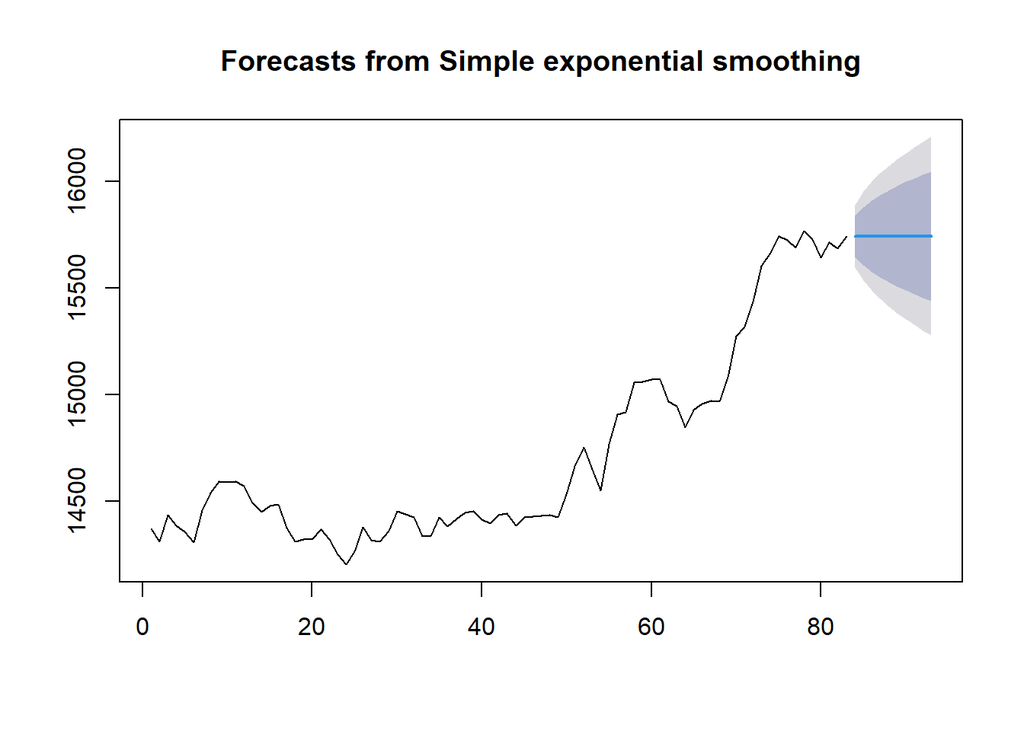

```r
#SES
ses.opt <- ses(train.ts, h = 10, alpha = NULL)
plot(ses.opt)
```

```r
ses.opt
```

```
##    Point Forecast    Lo 80    Hi 80    Lo 95    Hi 95
## 84       15742.52 15646.19 15838.84 15595.20 15889.83
## 85       15742.52 15606.30 15878.73 15534.19 15950.84
## 86       15742.52 15575.69 15909.34 15487.38 15997.66
## 87       15742.52 15549.88 15935.15 15447.91 16037.12
## 88       15742.52 15527.15 15957.89 15413.14 16071.90
## 89       15742.52 15506.59 15978.44 15381.70 16103.33
## 90       15742.52 15487.69 15997.34 15352.79 16132.24
## 91       15742.52 15470.09 16014.94 15325.88 16159.15
## 92       15742.52 15453.57 16031.46 15300.61 16184.42
## 93       15742.52 15437.94 16047.09 15276.71 16208.32
```

```r
#Lamda Optimum Holt Winter
HWopt<- HoltWinters(train.ts, gamma = FALSE, beta = FALSE,alpha = NULL)
HWopt
```

```
## Holt-Winters exponential smoothing without trend and without seasonal component.
##
## Call:
## HoltWinters(x = train.ts, alpha = NULL, beta = FALSE, gamma = FALSE)
##
## Smoothing parameters:
##  alpha: 0.9999224
##  beta : FALSE
##  gamma: FALSE
##
## Coefficients:
##       [,1]
## a 15742.52
```

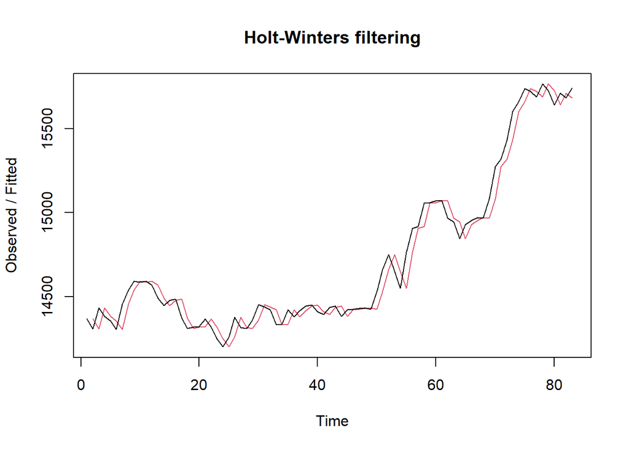

```r
plot(HWopt)
```

```r
#ramalan
ramalanopt<- forecast(HWopt, h=10)
ramalanopt
```

```
##    Point Forecast    Lo 80    Hi 80    Lo 95    Hi 95
## 84       15742.52 15648.65 15836.39 15598.95 15886.08
## 85       15742.52 15609.77 15875.27 15539.50 15945.54
## 86       15742.52 15579.94 15905.10 15493.87 15991.16
## 87       15742.52 15554.79 15930.25 15455.41 16029.63
## 88       15742.52 15532.63 15952.41 15421.52 16063.51
## 89       15742.52 15512.60 15972.44 15390.88 16094.15
## 90       15742.52 15494.18 15990.86 15362.71 16122.32
## 91       15742.52 15477.03 16008.01 15336.49 16148.55
## 92       15742.52 15460.92 16024.11 15311.86 16173.18
## 93       15742.52 15445.69 16039.34 15288.56 16196.47
```

Setelah dilakukan peramalan, akan dilakukan perhitungan keakuratan hasil peramalan. Perhitungan akurasi ini dilakukan baik pada data latih dan data uji.

#### Akurasi Data Latih

Perhitungan akurasi data dapat dilakukan dengan cara langsung maupun manual. Secara langsung, nilai akurasi dapat diambil dari objek yang tersimpan pada hasil SES, yaitu *sum of squared errors* (SSE). Nilai akurasi lain dapat dihitung pula dari nilai SSE tersebut.

```r
#Keakuratan Metode
#Pada data training

# SES dengan alpha = 0.2
SSE1<-ses1$SSE
MSE1<-ses1$SSE/length(train.ts)
RMSE1<-sqrt(MSE1)

akurasi1 <- matrix(c(SSE1,MSE1,RMSE1))
row.names(akurasi1)<- c("SSE", "MSE", "RMSE")
colnames(akurasi1) <- c("Akurasi lamda=0.2")
akurasi1
```

```
##      Akurasi lamda=0.2
## SSE       2040477.9738
## MSE         24584.0720
## RMSE          156.7931
```

```r
# SES dengan alpha = 0.7
SSE2<-ses2$SSE
MSE2<-ses2$SSE/length(train.ts)
RMSE2<-sqrt(MSE2)

akurasi2 <- matrix(c(SSE2,MSE2,RMSE2))
row.names(akurasi2)<- c("SSE", "MSE", "RMSE")
colnames(akurasi2) <- c("Akurasi lamda=0.7")
akurasi2
```

```
##      Akurasi lamda=0.7
## SSE       571386.00763
## MSE         6884.16877
## RMSE          82.97089
```

```r
#Cara Manual
# Alpha = 0.2
fitted1<-ramalan1$fitted
sisaan1<-ramalan1$residuals
head(sisaan1)
```

```
## Time Series:
## Start = 1
## End = 6
## Frequency = 1
## [1]        NA -61.30600  76.58120  11.21496 -18.56403 -64.70123
```

```r
resid1<-training$`Kurs Jual Rataan`-ramalan1$fitted
head(resid1)
```

```
## Time Series:
## Start = 1
## End = 6
## Frequency = 1
## [1]        NA -61.30600  76.58120  11.21496 -18.56403 -64.70123
```

```r
SSE.1=sum(sisaan1[2:length(train.ts)]^2)
SSE.1
```

```
## [1] 2040478
```

```r
MSE.1 = SSE.1/length(train.ts)
MSE.1
```

```
## [1] 24584.07
```

```r
MAPE.1 = sum(abs(sisaan1[2:length(train.ts)]/train.ts[2:length(train.ts)])*
               100)/length(train.ts)
MAPE.1
```

```
## [1] 0.7455643
```

```r
akurasi.1 <- matrix(c(SSE.1,MSE.1,MAPE.1))
row.names(akurasi.1)<- c("SSE", "MSE", "MAPE")
colnames(akurasi.1) <- c("Akurasi lamda=0.2")
akurasi.1
```

```
##      Akurasi lamda=0.2
## SSE       2.040478e+06
## MSE       2.458407e+04
## MAPE      7.455643e-01
```

```r
# Alpha = 0.7
fitted2<-ramalan2$fitted
sisaan2<-ramalan2$residuals
head(sisaan2)
```

```
## Time Series:
## Start = 1
## End = 6
## Frequency = 1
## [1]        NA -61.30600 107.23420 -17.87974 -32.89992 -59.71998
```

```r
resid2<-training$`Kurs Jual Rataan`-ramalan2$fitted
head(resid2)
```

```
## Time Series:
## Start = 1
## End = 6
## Frequency = 1
## [1]        NA -61.30600 107.23420 -17.87974 -32.89992 -59.71998
```

```r
SSE.2=sum(sisaan2[2:length(train.ts)]^2)
SSE.2
```

```
## [1] 571386
```

```r
MSE.2 = SSE.2/length(train.ts)
MSE.2
```

```
## [1] 6884.169
```

```r
MAPE.2 = sum(abs(sisaan2[2:length(train.ts)]/train.ts[2:length(train.ts)])*
               100)/length(train.ts)
MAPE.2
```

```
## [1] 0.4285728
```

```r
akurasi.2 <- matrix(c(SSE.2,MSE.2,MAPE.2))
row.names(akurasi.2)<- c("SSE", "MSE", "MAPE")
colnames(akurasi.2) <- c("Akurasi lamda=0.7")
akurasi.2
```

```
##      Akurasi lamda=0.7
## SSE       5.713860e+05
## MSE       6.884169e+03
## MAPE      4.285728e-01
```

#### Akurasi Data Uji

Akurasi data uji dapat dihitung dengan cara yang hampir sama dengan perhitungan akurasi data latih.

```r
# jumlah observasi uji
n_test <- nrow(testing)

# error (ramalan - aktual), samakan panjang dan tipe numeric
e1   <- as.numeric(ramalan1$mean)[1:n_test] - as.numeric(testing$`Kurs Jual Rataan`)
e2   <- as.numeric(ramalan2$mean)[1:n_test] - as.numeric(testing$`Kurs Jual Rataan`)
eopt <- as.numeric(ramalanopt$mean)[1:n_test] - as.numeric(testing$`Kurs Jual Rataan`)

# SSE / MSE / RMSE untuk masing-masing model (abaikan NA)
SSEtesting1  <- sum(e1^2,  na.rm = TRUE)
MSEtesting1  <- mean(e1^2, na.rm = TRUE)
RMSEtesting1 <- sqrt(MSEtesting1)

SSEtesting2  <- sum(e2^2,  na.rm = TRUE)
MSEtesting2  <- mean(e2^2, na.rm = TRUE)
RMSEtesting2 <- sqrt(MSEtesting2)

SSEtestingopt  <- sum(eopt^2,  na.rm = TRUE)
MSEtestingopt  <- mean(eopt^2, na.rm = TRUE)
RMSEtestingopt <- sqrt(MSEtestingopt)

# Tabel ringkas
akurasitesting_SSE <- matrix(c(SSEtesting1, SSEtesting2, SSEtestingopt),
                             nrow = 3,
                             dimnames = list(c("SSE1","SSE2","SSEopt"), "Nilai"))
akurasitesting_MSE <- matrix(c(MSEtesting1, MSEtesting2, MSEtestingopt),
                             nrow = 3,
                             dimnames = list(c("MSE1","MSE2","MSEopt"), "Nilai"))
akurasitesting_RMSE <- matrix(c(RMSEtesting1, RMSEtesting2, RMSEtestingopt),
                              nrow = 3,
                              dimnames = list(c("RMSE1","RMSE2","RMSEopt"), "Nilai"))

akurasitesting_SSE
```

```
##          Nilai
## SSE1   1636862
## SSE2   2147083
## SSEopt 2285587
```

```r
akurasitesting_MSE
```

```
##           Nilai
## MSE1   163686.2
## MSE2   214708.3
## MSEopt 228558.7
```

```r
akurasitesting_RMSE
```

```
##            Nilai
## RMSE1   404.5815
## RMSE2   463.3662
## RMSEopt 478.0782
```

## *Double Exponential Smoothing* (DES)

Metode pemulusan *Double Exponential Smoothing* (DES) digunakan untuk data yang memiliki pola tren. Metode DES adalah metode semacam SES, hanya saja dilakukan dua kali, yaitu pertama untuk tahapan ‘level’ dan kedua untuk tahapan ‘tren’. Pemulusan menggunakan metode ini akan menghasilkan peramalan tidak konstan untuk `Minggu Ke-t` berikutnya.

Pemulusan dengan metode DES kali ini akan menggunakan fungsi `HoltWinters()` . Jika sebelumnya nilai argumen `beta` dibuat `FALSE` , kali ini argumen tersebut akan diinisialisasi bersamaan dengan nilai `alpha` .

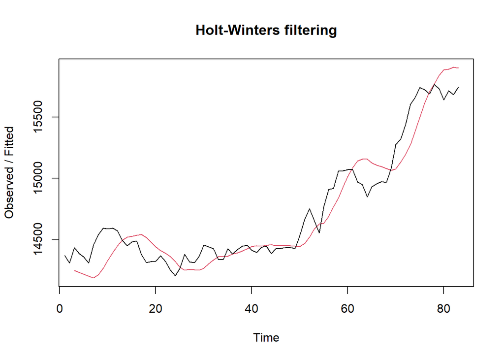

```r
#Lamda=0.2 dan gamma=0.2
des.1<- HoltWinters(train.ts, gamma = FALSE, beta = 0.2, alpha = 0.2)
plot(des.1)
```

```r
#ramalan
ramalandes1<- forecast(des.1, h=10)
ramalandes1
```

```
##    Point Forecast    Lo 80    Hi 80    Lo 95    Hi 95
## 84       15902.60 15710.35 16094.85 15608.58 16196.63
## 85       15936.23 15738.52 16133.94 15633.86 16238.60
## 86       15969.86 15764.95 16174.77 15656.48 16283.24
## 87       16003.49 15789.54 16217.43 15676.29 16330.69
## 88       16037.12 15812.26 16261.98 15693.22 16381.01
## 89       16070.74 15833.10 16308.39 15707.29 16434.20
## 90       16104.37 15852.12 16356.63 15718.58 16490.16
## 91       16138.00 15869.40 16406.61 15727.21 16548.80
## 92       16171.63 15885.03 16458.23 15733.31 16609.95
## 93       16205.26 15899.10 16511.42 15737.03 16673.49
```

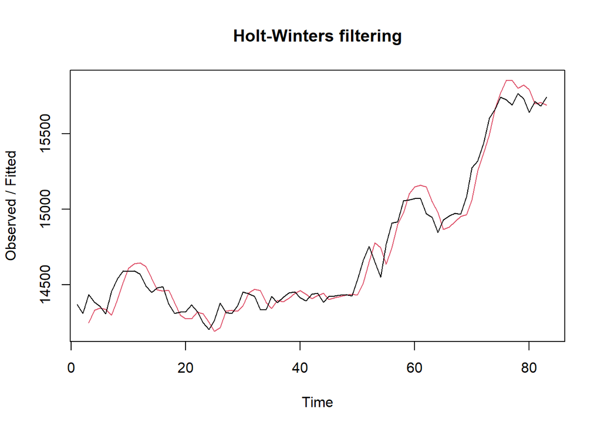

```r
#Lamda=0.6 dan gamma=0.3
des.2<- HoltWinters(train.ts, gamma = FALSE, beta = 0.3, alpha = 0.6)
plot(des.2)
```

```r
#ramalan
ramalandes2<- forecast(des.2, h=10)
ramalandes2
```

```
##    Point Forecast    Lo 80    Hi 80    Lo 95    Hi 95
## 84       15726.75 15613.14 15840.37 15553.00 15900.51
## 85       15732.39 15588.30 15876.48 15512.03 15952.76
## 86       15738.03 15557.32 15918.75 15461.65 16014.41
## 87       15743.67 15521.34 15966.01 15403.64 16083.71
## 88       15749.31 15481.13 16017.50 15339.16 16159.47
## 89       15754.95 15437.20 16072.71 15268.99 16240.92
## 90       15760.60 15389.92 16131.27 15193.70 16327.49
## 91       15766.24 15339.55 16192.92 15113.68 16418.79
## 92       15771.88 15286.31 16257.44 15029.26 16514.49
## 93       15777.52 15230.35 16324.68 14940.69 16614.34
```

Untuk mendapatkan nilai parameter optimum dari DES, argumen `alpha` dan `beta` dapat dibuat `NULL` seperti berikut.

```r
#Lamda dan gamma optimum
des.opt<- HoltWinters(train.ts, gamma = FALSE)
des.opt
```

```
## Holt-Winters exponential smoothing with trend and without seasonal component.
##
## Call:
## HoltWinters(x = train.ts, gamma = FALSE)
##
## Smoothing parameters:
##  alpha: 1
##  beta : 0.0998858
##  gamma: FALSE
##
## Coefficients:
##          [,1]
## a 15742.52200
## b    28.65512
```

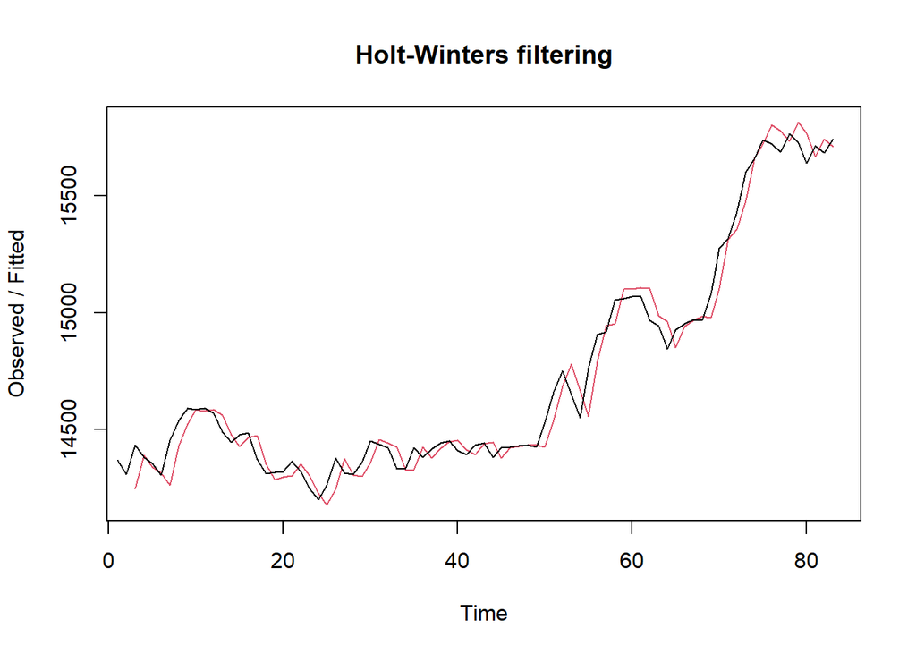

```r
plot(des.opt)
```

```r
#ramalan
ramalandesopt<- forecast(des.opt, h=10)
ramalandesopt
```

```
##    Point Forecast    Lo 80    Hi 80    Lo 95    Hi 95
## 84       15771.18 15673.70 15868.66 15622.10 15920.26
## 85       15799.83 15654.93 15944.74 15578.22 16021.45
## 86       15828.49 15642.27 16014.70 15543.70 16113.28
## 87       15857.14 15631.92 16082.37 15512.69 16201.59
## 88       15885.80 15622.48 16149.12 15483.08 16288.51
## 89       15914.45 15613.29 16215.62 15453.86 16375.05
## 90       15943.11 15603.98 16282.23 15424.46 16461.76
## 91       15971.76 15594.35 16349.18 15394.56 16548.97
## 92       16000.42 15584.25 16416.59 15363.94 16636.90
## 93       16029.07 15573.59 16484.55 15332.47 16725.67
```

Selanjutnya akan dilakukan perhitungan akurasi pada data latih maupun data uji dengan ukuran akurasi SSE, MSE dan MAPE.

#### Akurasi Data Latih

```r
#Akurasi Data Training
ssedes.train1<-des.1$SSE
msedes.train1<-ssedes.train1/length(train.ts)
sisaandes1<-ramalandes1$residuals
head(sisaandes1)
```

```
## Time Series:
## Start = 1
## End = 6
## Frequency = 1
## [1]       NA       NA 186.9320 153.3243 142.8192 106.3883
```

```r
mapedes.train1 <- sum(abs(sisaandes1[3:length(train.ts)]/train.ts[3:length(train.ts)])
                      *100)/length(train.ts)

akurasides.1 <- matrix(c(ssedes.train1,msedes.train1,mapedes.train1))
row.names(akurasides.1)<- c("SSE", "MSE", "MAPE")
colnames(akurasides.1) <- c("Akurasi lamda=0.2 dan gamma=0.2")
akurasides.1
```

```
##      Akurasi lamda=0.2 dan gamma=0.2
## SSE                     1.869907e+06
## MSE                     2.252900e+04
## MAPE                    8.050659e-01
```

```r
ssedes.train2<-des.2$SSE
msedes.train2<-ssedes.train2/length(train.ts)
sisaandes2<-ramalandes2$residuals
head(sisaandes2)
```

```
## Time Series:
## Start = 1
## End = 6
## Frequency = 1
## [1]        NA        NA 186.93200  52.38104  11.64607 -29.05821
```

```r
mapedes.train2 <- sum(abs(sisaandes2[3:length(train.ts)]/train.ts[3:length(train.ts)])
                      *100)/length(train.ts)

akurasides.2 <- matrix(c(ssedes.train2,msedes.train2,mapedes.train2))
row.names(akurasides.2)<- c("SSE", "MSE", "MAPE")
colnames(akurasides.2) <- c("Akurasi lamda=0.6 dan gamma=0.3")
akurasides.2
```

```
##      Akurasi lamda=0.6 dan gamma=0.3
## SSE                     6.304657e+05
## MSE                     7.595973e+03
## MAPE                    4.633943e-01
```

Hasil akurasi dari data latih didapatkan skenario 2 dengan lamda=0.6 dan gamma=0.3 memiliki hasil yang lebih baik. Namun untuk kedua skenario dapat dikategorikan peramalan sangat baik berdasarkan nilai MAPE-nya.

#### Akurasi Data Uji

```r
#Akurasi Data Testing
selisihdes1<-ramalandes1$mean-testing[1:10,]$`Kurs Jual Rataan`
selisihdes1
```

```
## Time Series:
## Start = 84
## End = 93
## Frequency = 1
##  [1]  220.1800  412.3966  785.5172  966.8777 1001.5143  847.6089  847.4675
##  [8]  847.1280  821.2626  710.1692
```

```r
SSEtestingdes1<-sum(selisihdes1^2)
MSEtestingdes1<-SSEtestingdes1/length(testing$`Kurs Jual Rataan`)
MAPEtestingdes1<-sum(abs(selisihdes1/testing[1:10,]$`Kurs Jual Rataan`)*100)/length(testing$`Kurs Jual Rataan`)

selisihdes2<-ramalandes2$mean-testing[1:10,]$`Kurs Jual Rataan`
selisihdes2
```

```
## Time Series:
## Start = 84
## End = 93
## Frequency = 1
##  [1]  44.3313 208.5596 553.6919 707.0643 713.7126 531.8189 503.6892 475.3615
##  [9] 421.5078 282.4262
```

```r
SSEtestingdes2<-sum(selisihdes2^2)
MSEtestingdes2<-SSEtestingdes2/length(testing$`Kurs Jual Rataan`)
MAPEtestingdes2<-sum(abs(selisihdes2/testing[1:10,]$`Kurs Jual Rataan`)*100)/length(testing[1:10,]$`Kurs Jual Rataan`)

selisihdesopt<-ramalandesopt$mean-testing[1:10,]$`Kurs Jual Rataan`
selisihdesopt
```

```
## Time Series:
## Start = 84
## End = 93
## Frequency = 1
##  [1]  88.75512 275.99823 644.14535 820.53246 850.19558 691.31669 686.20181
##  [8] 680.88893 650.05004 533.98316
```

```r
SSEtestingdesopt<-sum(selisihdesopt^2)
MSEtestingdesopt<-SSEtestingdesopt/length(testing$`Kurs Jual Rataan`)
MAPEtestingdesopt<-sum(abs(selisihdesopt/testing[1:10,]$`Kurs Jual Rataan`)*100)/length(testing[1:10,]$`Kurs Jual Rataan`)

akurasitestingdes <-
  matrix(c(SSEtestingdes1,MSEtestingdes1,MAPEtestingdes1,SSEtestingdes2,MSEtestingdes2,
           MAPEtestingdes2,SSEtestingdesopt,MSEtestingdesopt,MAPEtestingdesopt),
         nrow=3,ncol=3)
row.names(akurasitestingdes)<- c("SSE", "MSE", "MAPE")
colnames(akurasitestingdes) <- c("des ske1","des ske2","des opt")
akurasitestingdes
```

```
##          des ske1     des ske2      des opt
## SSE  6.106551e+06 2.381299e+06 4.015186e+06
## MSE  3.053276e+05 1.190649e+05 2.007593e+05
## MAPE 2.446039e+00 2.919399e+00 3.887015e+00
```

#### Perbandingan SES dan DES

```r
MSEfull <-
  matrix(c(MSEtesting1,MSEtesting2,MSEtestingopt,MSEtestingdes1,MSEtestingdes2,
           MSEtestingdesopt),nrow=3,ncol=2)
row.names(MSEfull)<- c("ske 1", "ske 2", "ske opt")
colnames(MSEfull) <- c("ses","des")
MSEfull
```

```
##              ses      des
## ske 1   163686.2 305327.6
## ske 2   214708.3 119064.9
## ske opt 228558.7 200759.3
```

Kedua metode dapat dibandingkan dengan menggunakan ukuran akurasi yang sama. Contoh di atas adalah perbandingan kedua metode dengan ukuran akurasi MSE. Hasilnya didapatkan metode DES lebih baik dibandingkan metode SES dilihat dari MSE yang lebih kecil nilainya.

```r
Perbandingan <- data.frame(
  SMA = akurasi_test.sma,
  DMA = akurasi_test.dma,
  SES = akurasi2,
  DES = akurasitestingdes
)

Perbandingan
```

```
##      Akurasi.m...4 Akurasi.m...4.1 Akurasi.lamda.0.7 DES.des.ske1 DES.des.ske2
## SSE   7.022629e+06    5.843114e+06      571386.00763 6.106551e+06 2.381299e+06
## MSE   3.511314e+05    2.921557e+05        6884.16877 3.053276e+05 1.190649e+05
## MAPE  3.572613e+00    3.239236e+00          82.97089 2.446039e+00 2.919399e+00
##       DES.des.opt
## SSE  4.015186e+06
## MSE  2.007593e+05
## MAPE 3.887015e+00
```

```r
Perbandingan
```

```
##      Akurasi.m...4 Akurasi.m...4.1 Akurasi.lamda.0.7 DES.des.ske1 DES.des.ske2
## SSE   7.022629e+06    5.843114e+06      571386.00763 6.106551e+06 2.381299e+06
## MSE   3.511314e+05    2.921557e+05        6884.16877 3.053276e+05 1.190649e+05
## MAPE  3.572613e+00    3.239236e+00          82.97089 2.446039e+00 2.919399e+00
##       DES.des.opt
## SSE  4.015186e+06
## MSE  2.007593e+05
## MAPE 3.887015e+00
```